# Warsztaty ggplot2

### Statystyki i geometrie:

Kolejne wartswy nakładane na wykres to między innymi statystyki i geometrie. Statystyki służą do agregacji danych, natomiast zadaniem geometrii jest graficzna reprezentacja wartości liczbowych. Każda statystyka wymaga geometrii i na odwrót - każda geometria wymaga statystyki. Bardzo często są określone w sposób domyślny, co można sprawdzić w dokumentacji, ale mogą też zostać ręcznie zmienione:

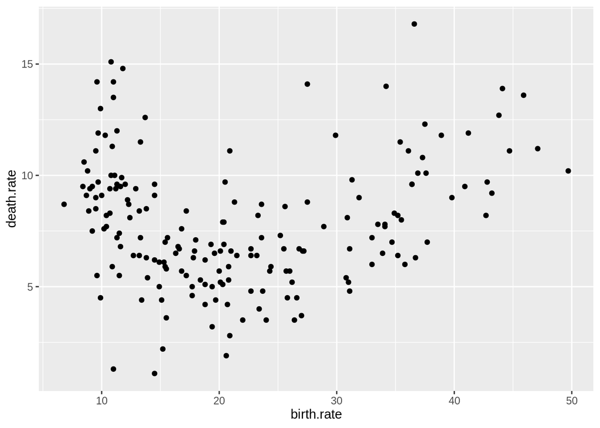

```r
p <- ggplot(countries, aes(x = birth.rate, y = death.rate)) +
  geom_point()
#to samo co
#ggplot(countries, aes(x = birth.rate, y = death.rate)) +
# geom_point(stat = 'identity')
p
```

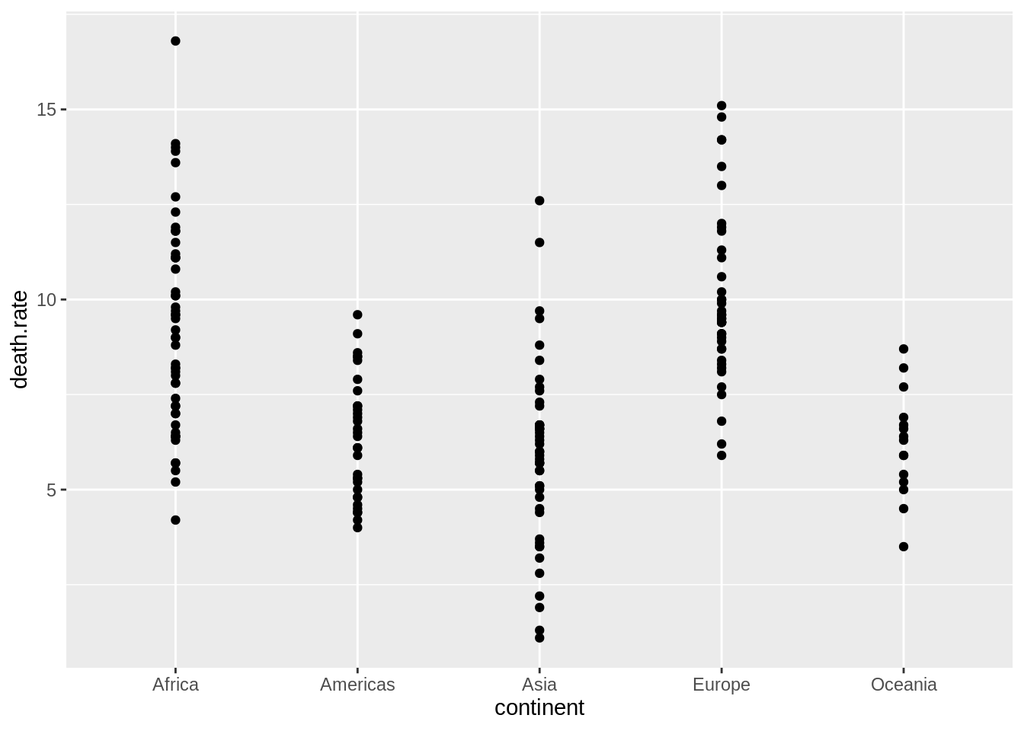

```r
p <- ggplot(data = countries, aes(x = continent, y = death.rate)) +
  geom_point()
#to samo co
#ggplot(countries, aes(x = continent, y = death.rate)) +
# geom_point(stat = 'identtity')
p
```

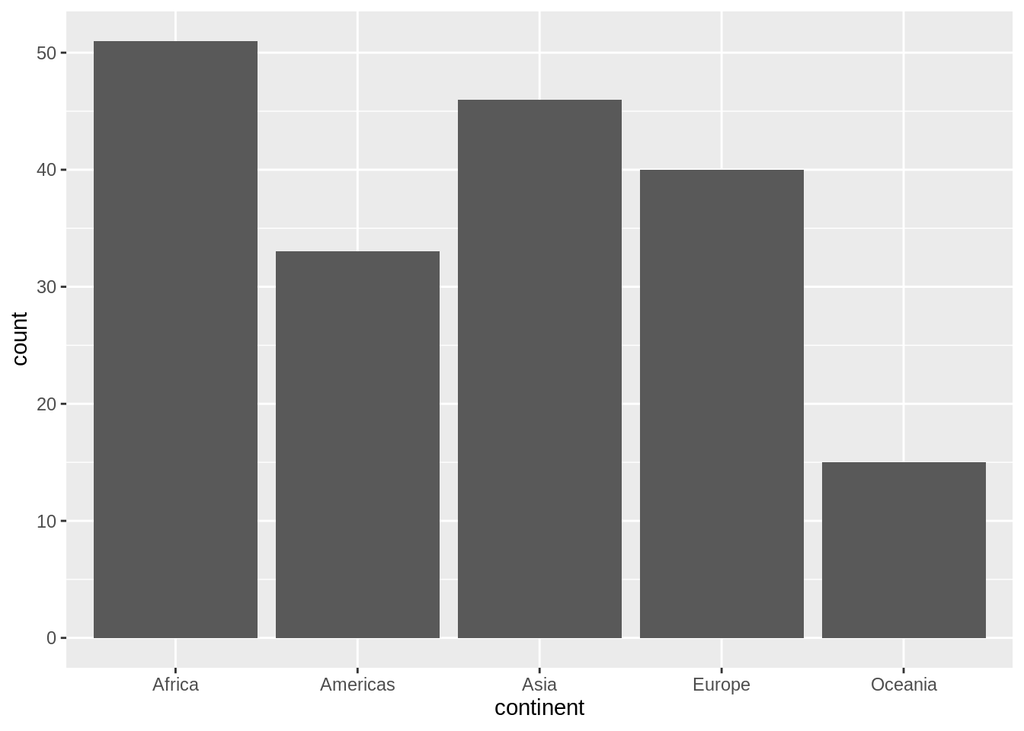

```r
p <- ggplot(countries, aes(x = continent)) +
  geom_bar()
#to samo co
#ggplot(countries, aes(x = continent)) +
# geom_bar(stat = 'count')
p
```

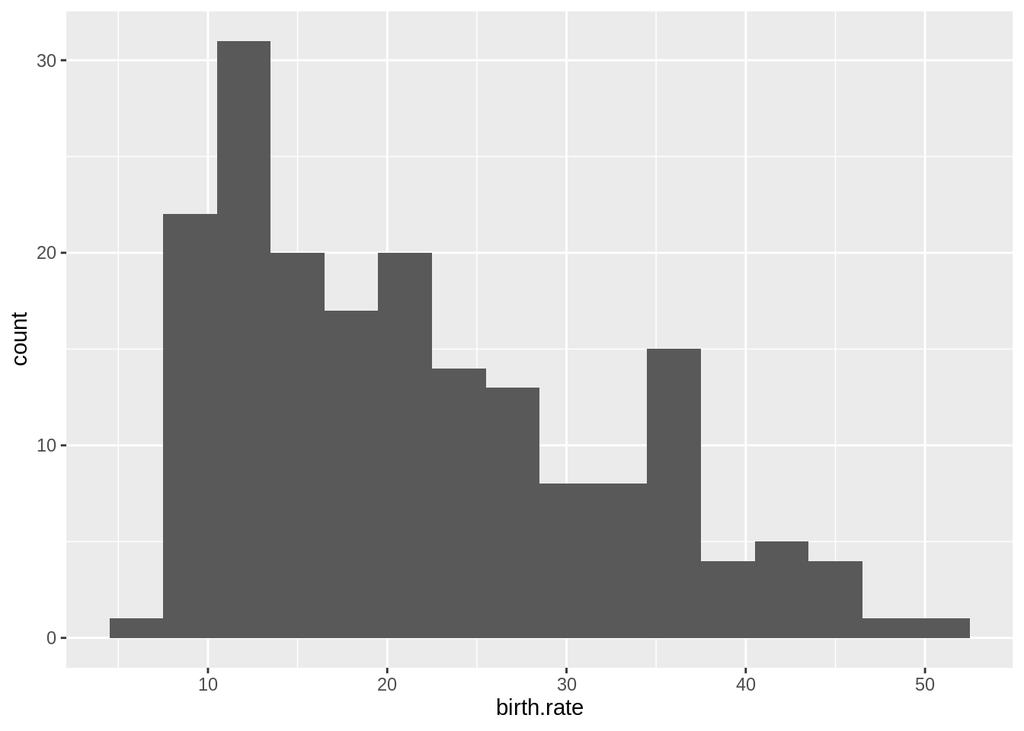

```r
p <- ggplot(countries, aes(x = birth.rate)) +
  stat_bin(binwidth = 3)
#to samo co
#ggplot(countries, aes(x = birth.rate)) +
# stat_bin(binwidth = 3, geom = 'bar')
p
```

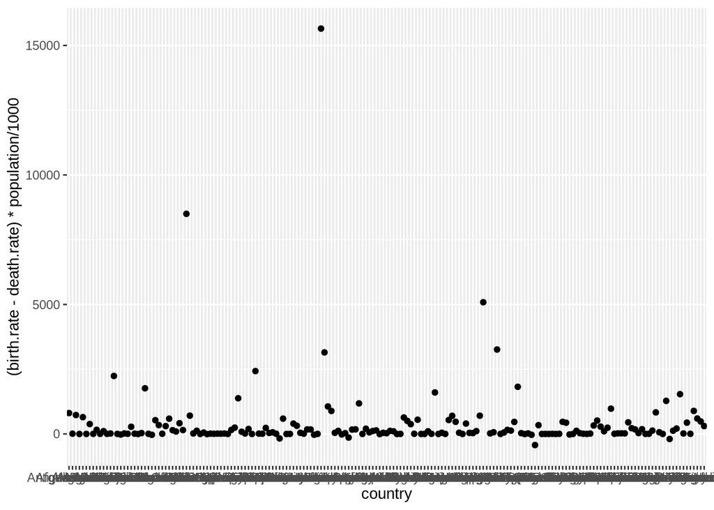

```r
#Zauważmy, że oś y zostaje nazwana tak jak określimy ją w aes()
#Bilans ludności:
ggplot(countries, aes(x = country, y = (birth.rate-death.rate)*population/1000)) +
         geom_point()
```

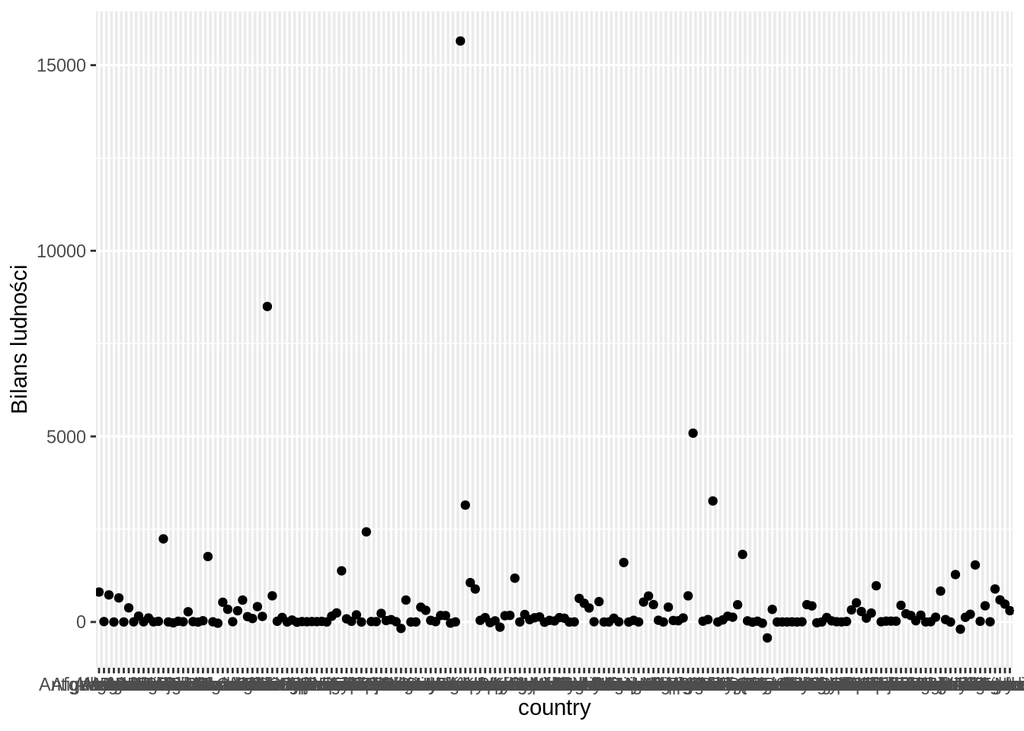

```r
#Jak zmienić tytuł osi y? Funkcja ylab (Dla osi x - xlab()):
ggplot(countries, aes(x = country, y = (birth.rate-death.rate)*population/1000)) +
  geom_point() +
  ylab("Bilans ludności")
```

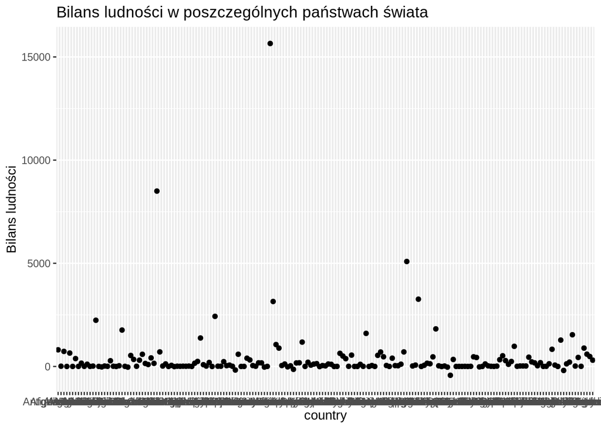

```r
#Jak dodać tytuł wykresu? Funkcja ggtitle():

ggplot(countries, aes(x = country, y = (birth.rate-death.rate)*population/1000)) +
  geom_point() +
  ylab("Bilans ludności") +
  ggtitle("Bilans ludności w poszczególnych państwach świata")
```

Lista wszystkich dostępnych geometrii dostępna jest pod linkiem: https://ggplot2.tidyverse.org/reference/

# Mapowanie

Wykresy to tak naprawdę wizualizacje wartości danych dla określonych obiektów. Prezentację możemy zaplanować w różny sposób, korzystając z mapowania za pomocą funkcji `aes()`. Każdy rodzaj geometrii przyjmuje różne możliwe mapowania (a niektórych wymaga), ich lista znajduje się oczywiście w dokumentacji funkcji.

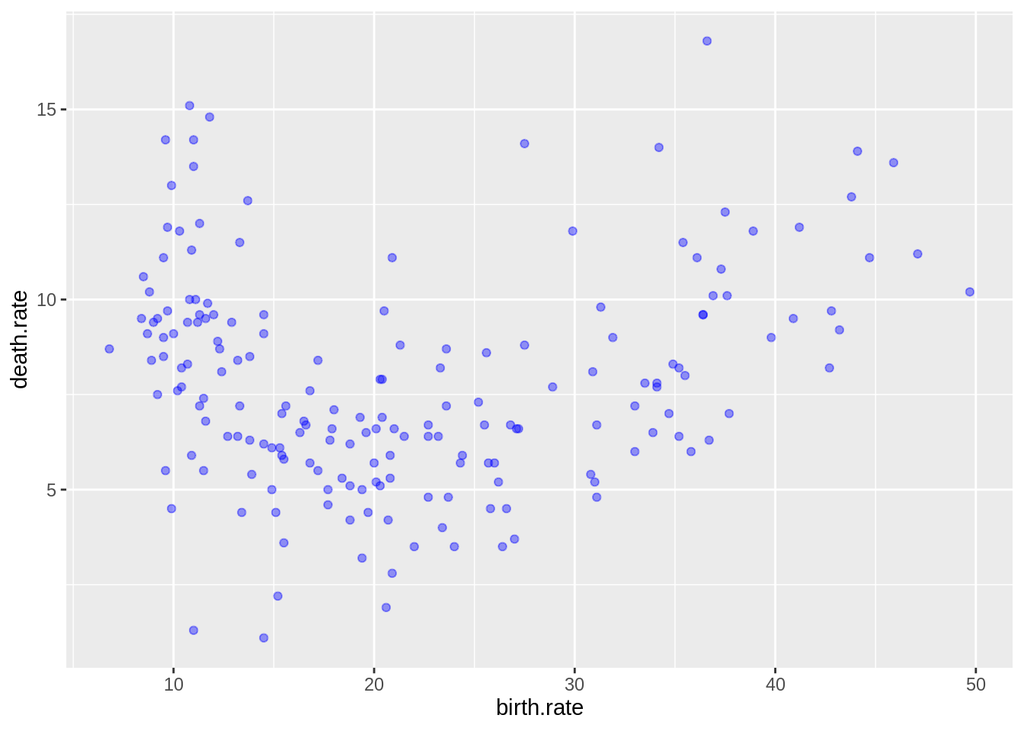

```r
#kolor i przezroczystość punktów nie jest zależna od danych, więc nie jest częścią mapowania, a własnością geom_point()
ggplot(data = countries, aes(x = birth.rate, y = death.rate)) +
  geom_point(color = "blue", alpha = 0.4)
```

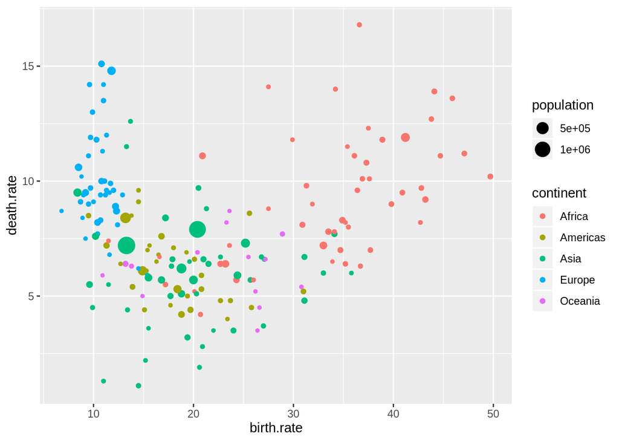

```r
#kolor i rozmiar punktów jest zależna od danych, więc jest częścią mapowania
ggplot(countries, aes(x = birth.rate, y = death.rate, colour = continent, size = population)) +
  geom_point()
```

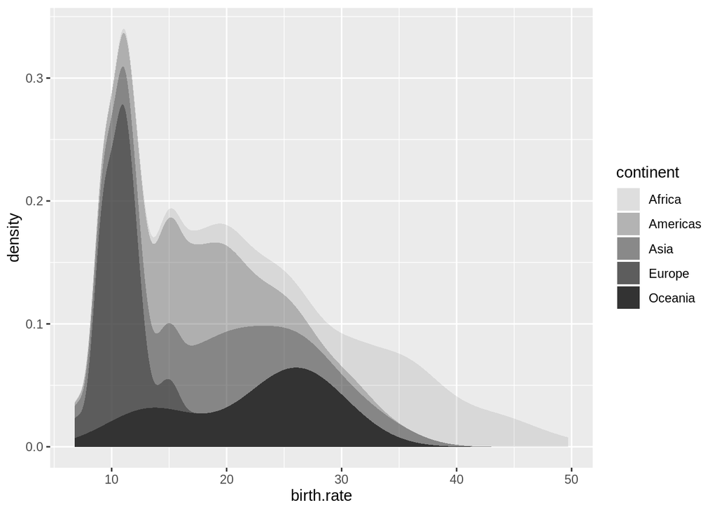

```r
#Parametr alpha dla zmiennej dyskretnej:
ggplot(countries, aes(x = birth.rate, alpha = continent)) +
  stat_density()
```

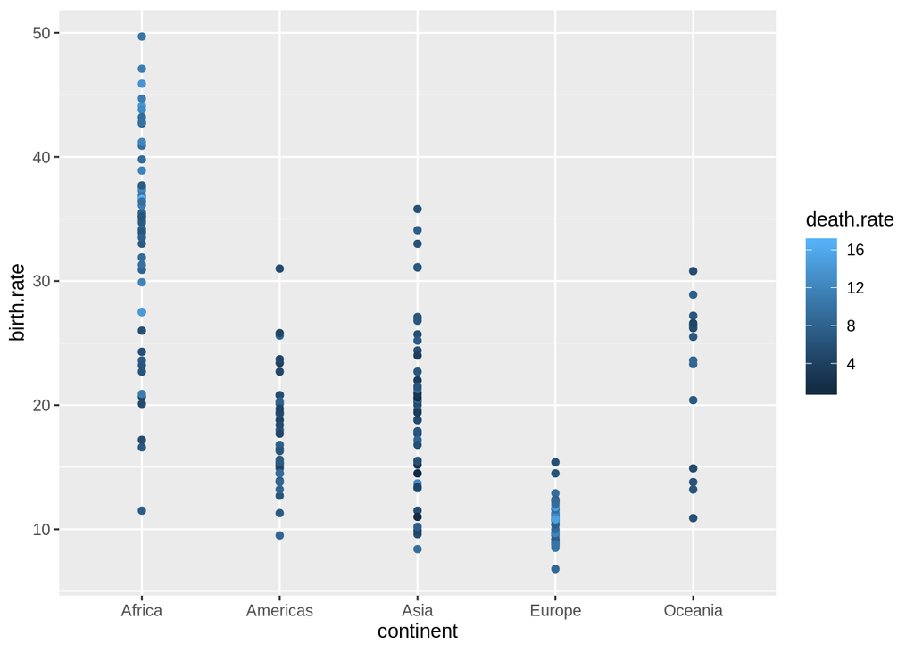

```r
#Zachowanie parametru color dla zmiennej ciągłej:
ggplot(countries, aes(x = continent, y = birth.rate, color = death.rate)) +
  geom_point()
```

# Dodawanie geometrii:

Biblioteka `ggplot2` umożliwia nam dodanie szerokiej gamy rodzajów wykresów w bardzo łatwy sposób. Co istotne, geometrie mogą być ze sobą łączone w ramach jednego wykresu:

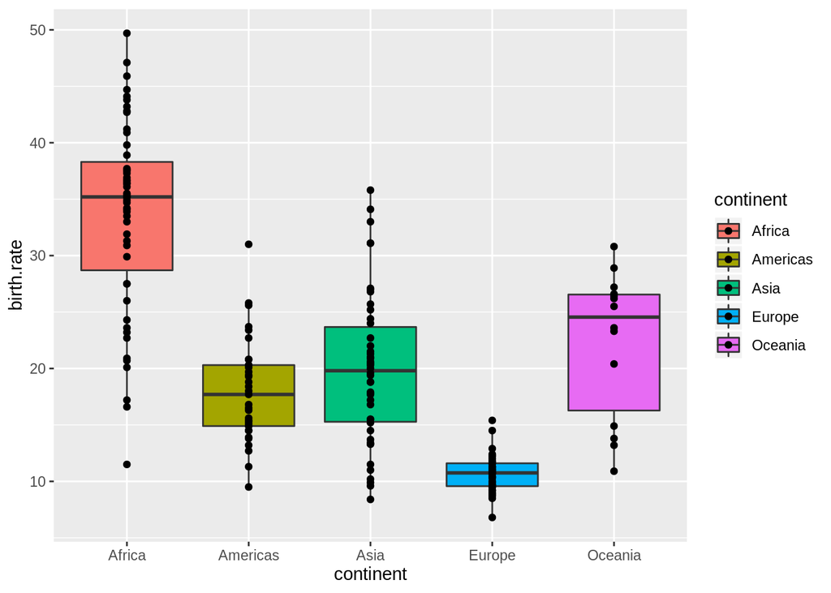

```r
# Warstwy geometrii zgadzają sie z kolejnością wywołań
ggplot(countries, aes(x = continent, y = birth.rate, fill = continent)) +
  geom_boxplot(outlier.color = NA) + # w celu unikniecia dublowania outlierow z geom_point
  geom_point()
```

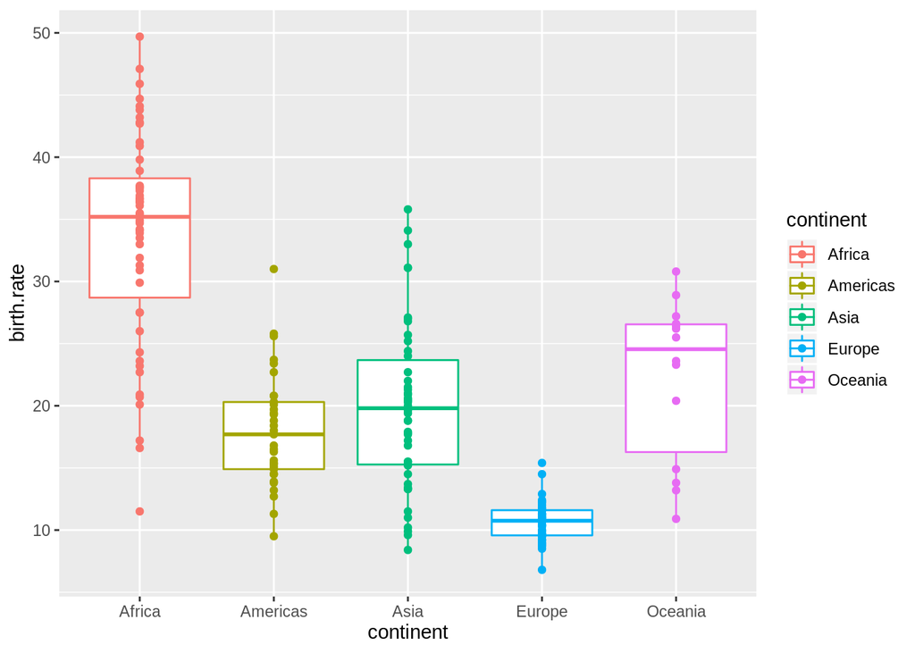

```r
# Zauważmy różnicę między fill a color, także w kontekście geom_point:
ggplot(countries, aes(x = continent, y = birth.rate, color = continent)) +
  geom_boxplot(outlier.color = NA) +
  geom_point()
```

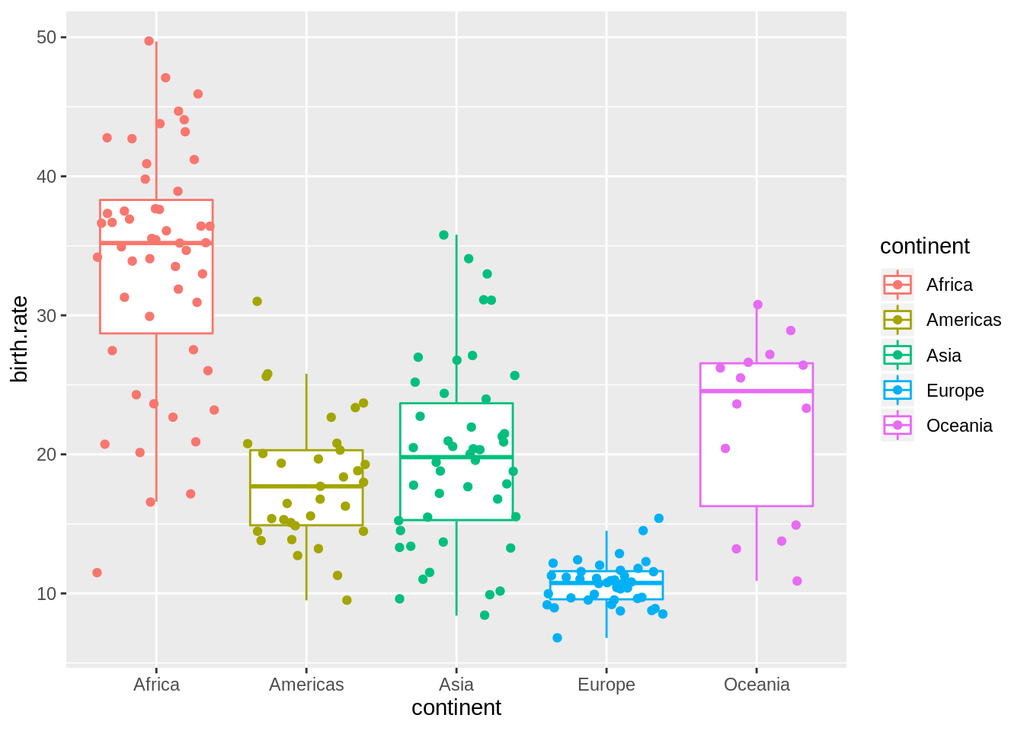

```r
# Oczywiście funkcje geometrii mają swoje parametry - tu: losowe rozmieszczenie punktów względem przedziału osi x
ggplot(countries, aes(x = continent, y = birth.rate, color = continent)) +
  geom_boxplot(outlier.color = NA) +
  geom_point(position = "jitter")
```

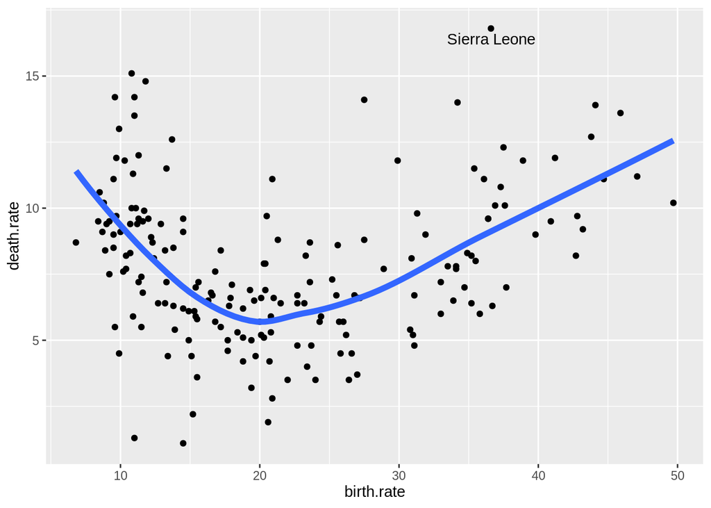

```r
ggplot(countries, aes(x=birth.rate, y=death.rate, label = country)) +
  geom_point() +
  geom_smooth(se=FALSE, size=2) +
  geom_text(data = countries[which.max(countries[["death.rate"]]),], vjust = 1.5)
```

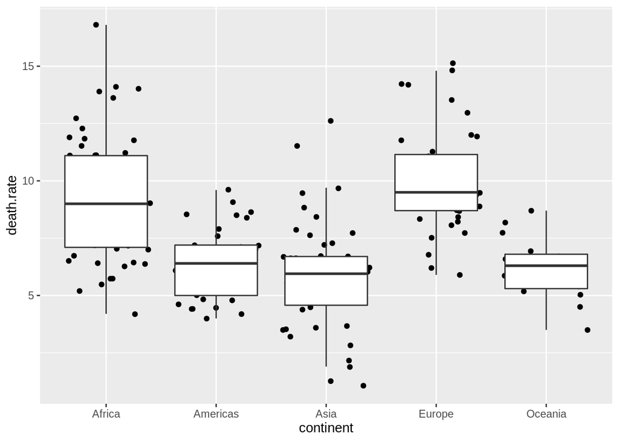

```r
ggplot(data = countries, aes(x = continent, y = death.rate)) +
  geom_point(position = "jitter") +
  geom_boxplot(outlier.color = NA)
```

# Przykłady innych elementów gramatyki:

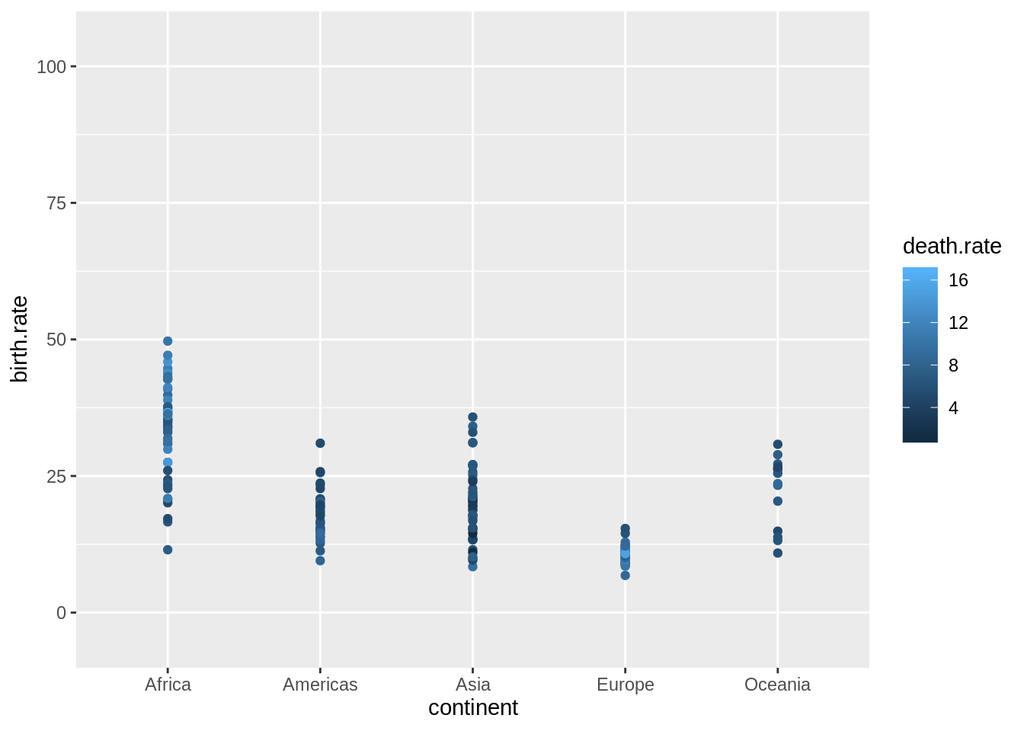

```r
#Miary
ggplot(countries, aes(x = continent, y = birth.rate, color = death.rate)) +
  geom_point() +
  scale_y_continuous(limits = c(0, 100), expand = c(0.1, 0.1))
```

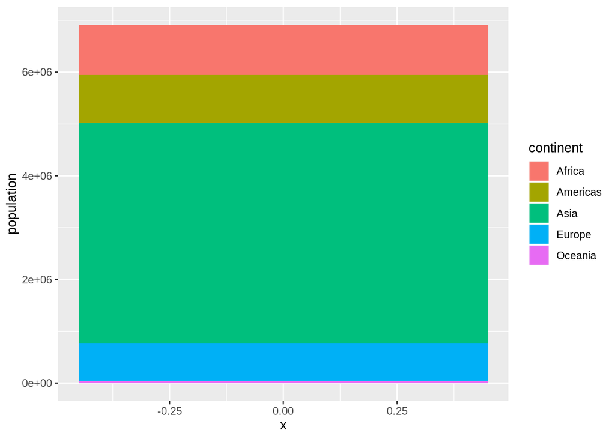

```r
#Przesuniecia
ggplot(countries, aes(fill = continent, y = population, x = 0)) +
  geom_bar(position = "stack", stat = "identity")
```

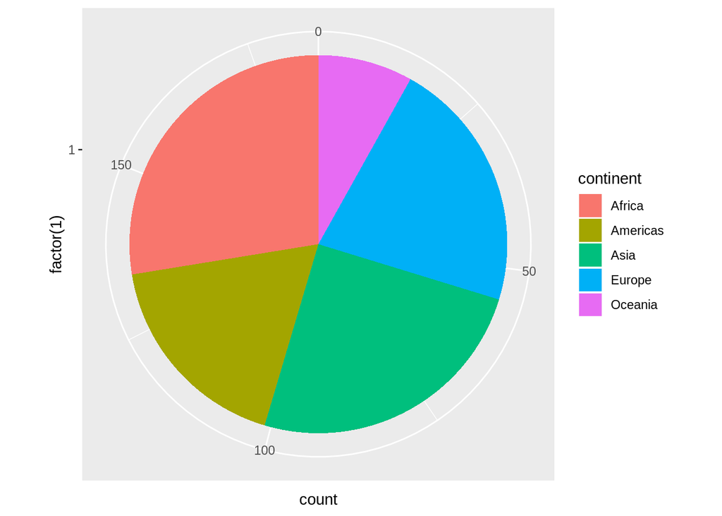

```r
#Uklad wspolrzednych
ggplot(countries, aes(x = factor(1), fill = continent)) +
  geom_bar(width = 1) +
  coord_polar("y")
```

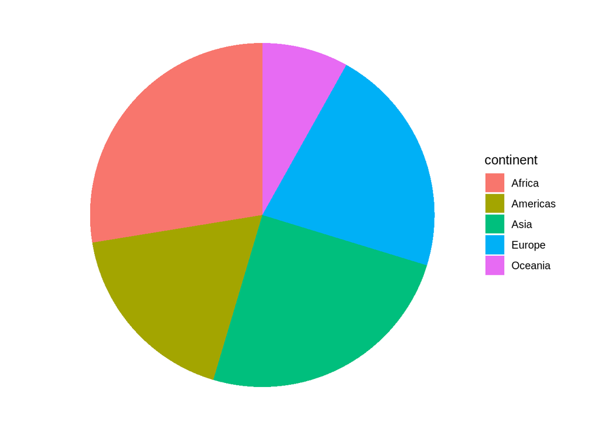

```r
#Dekoracje
ggplot(countries, aes(x = factor(1), fill = continent)) +
  geom_bar(width = 1) +
  coord_polar("y") +
  theme_void()
```

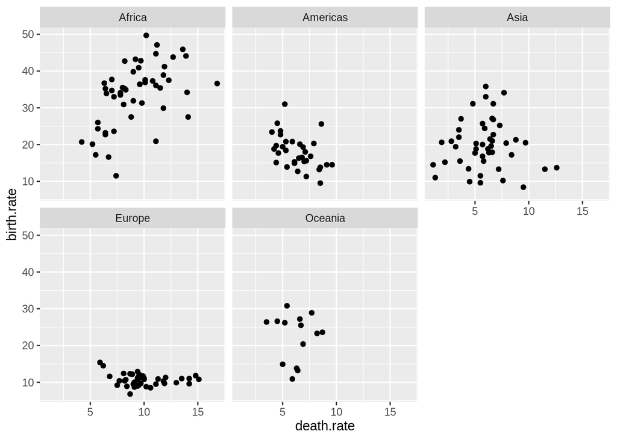

```r
#Panele
ggplot(countries, aes(x = death.rate, y = birth.rate)) +
  geom_point() +
  facet_wrap(vars(continent))
```

# Zadanie do wykonania

Stwórz następujące wykresy:

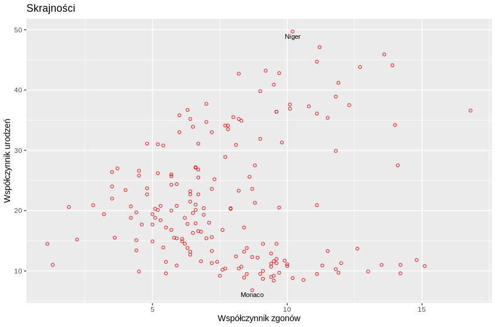

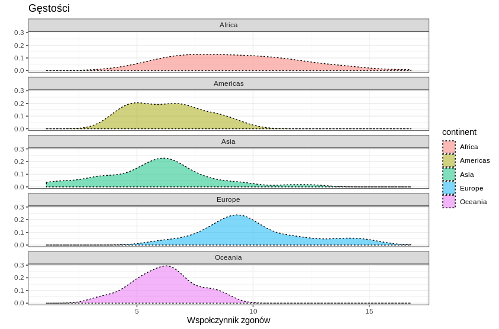

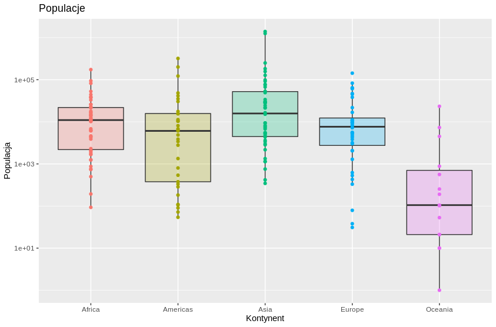

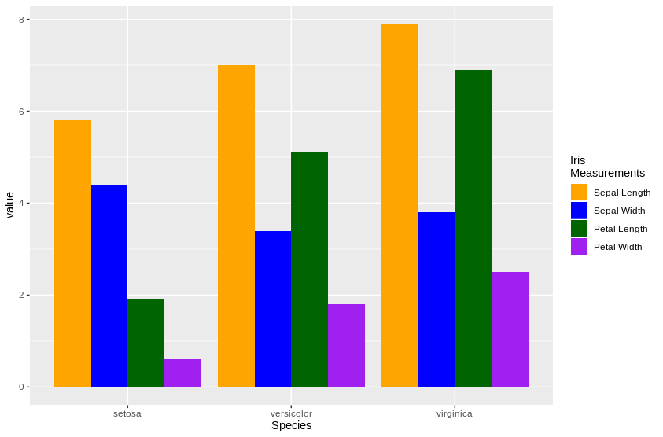